# Additional material (Annual Review of Linguistics article)

Shravan Vasishth

3/17/2022

```r
knitr::opts_chunk$set(echo = TRUE)
library(lme4)
```

```r
library(MASS)
library(ggplot2)
library(ggridges)
library(gridExtra)
library(bayesplot)
library(brms)
```

# Introduction

This is the code to accompany the paper Some right ways to analyze (psycho)linguistic data. The paper is available from: https://osf.io/5wzyg/

I assume that the user has at least glanced at the paper before working through this document.

# Function definitions

## t-test summary

```r
## ----summaryttestfunction---------------------------------------------------------------
## define function to summarize t-test results:
summary_ttest <- function(res, paired = TRUE, units = "ms") {
  obs_t <- round(res$statistic, 2)
  dfs <- round(res$parameter)
  pval <- round(res$p.value, 3)
  ci <- round(res$conf.int, 2)
  est <- round(res$estimate, 2)
  if (paired == TRUE) {
    list(dfs,obs_t,pval,est,ci[1],ci[2])
  } else {
    list(dfs,obs_t,pval,est[1],est[2],ci[1],ci[2])
    }
}
```

## Compute MinF’

```r
 minf <- function(f1,f2,n1,n2){
 fprime <- (f1*f2)/(f1+f2)
 n <- round(((f1+f2)*(f1+f2))/(((f1*f1)/n2)+((f2*f2)/n1)))
 return(paste("minF(",n,")=",round(fprime,digits=2),", crit=",round(qf(.95,1,n)),sep=""))
  }
## ## usage:
## minf(f1=6.92,f2=4.62,n1=36,n2=14)
## pf(2.77,df1=1,df2=33,lower.tail=FALSE)

## ----runminf,echo=TRUE,eval=FALSE-----------------------------------------------------------------
## minf(f1=12.1,f2=4.14,n1=36,n2=14)
## pf(3.08,df1=1,df2=24,lower.tail=FALSE)
```

## Generate fake lognormal data

```r
## ----genfakelnorm-----------------------------------------------------------------------
# assumes that no. of subjects and no. of items is divisible by 2.
gen_fake_lnorm <- function(nitem = 16,
                           nsubj = 42,
                           beta = c(6, 0.12),
                           ranefsd = c(0.32, 0.22, 0.04, 0.09),
                           corr = c(.6, .6),
                           sigma_e = 0.31) {
  ## prepare data frame for two condition latin square:
  g1 <- data.frame(
    item = 1:nitem,
    condition = rep(
      letters[1:2],
      nitem / 2
    )
  )
  g2 <- data.frame(
    item = 1:nitem,
    condition = rep(
      letters[2:1],
      nitem / 2
    )
  )

  ## assemble data frame:
  fakedat <- rbind(
    g1[rep(
      seq_len(nrow(g1)),
      nsubj / 2
    ), ],
    g2[rep(
      seq_len(nrow(g2)),
      nsubj / 2
    ), ]
  )

  ## add subjects:
  fakedat$subj <- rep(1:nsubj, each = nitem)

  ## add contrast coding:
  fakedat$cond <- ifelse(fakedat$condition == "a", -1 / 2, 1 / 2)

  ## Define variance covariance matrices:
  Sigma_u <- matrix(c(
    ranefsd[1]^2,
    corr[1] * ranefsd[1] * ranefsd[2],
    corr[1] * ranefsd[1] * ranefsd[2],
    ranefsd[2]^2
  ), nrow = 2)

  Sigma_w <- matrix(c(
    ranefsd[3]^2,
    corr[2] * ranefsd[3] * ranefsd[4],
    corr[2] * ranefsd[3] * ranefsd[4],
    ranefsd[4]^2
  ), nrow = 2)

  ## subj ranef
  u <- MASS::mvrnorm(
    n = length(unique(fakedat$subj)),
    mu = c(0, 0), Sigma = Sigma_u
  )
  # item ranef
  w <- MASS::mvrnorm(
    n = length(unique(fakedat$item)),
    mu = c(0, 0), Sigma = Sigma_w
  )

  ## generate data:
  N <- dim(fakedat)[1]
  rt <- rep(NA, N)
  for (i in 1:N) {
    rt[i] <- rlnorm(1, beta[1] +
      u[fakedat[i, ]$subj, 1] +
      w[fakedat[i, ]$item, 1] +
      (beta[2] +
        u[fakedat[i, ]$subj, 2] +
        w[fakedat[i, ]$item, 2]) * fakedat$cond[i], sigma_e)
  }

  fakedat$rt <- rt
  fakedat
}
```

## Generate fake normal data

```r
## ----genfakenorm,echo=TRUE------------------------------------------------------------------------
 ## Define function to generate normally distributed LMM data:
 gen_fake_norm <- function(nitem = 16,
                           nsubj = 42,
                           beta = c(420, 102),
                           ranefsd = c(154, 149, 37, 60),
                           corr = c(.6, .6),
                           sigma_e = 305) {
  ## prepare data frame for two condition latin square:
  g1 <- data.frame(
    item = 1:nitem,
    condition = rep(
      letters[1:2],
      nitem / 2
    )
  )
  g2 <- data.frame(
    item = 1:nitem,
    condition = rep(
      letters[2:1],
      nitem / 2
    )
  )

  ## assemble data frame:
  fakedat <- rbind(
    g1[rep(
      seq_len(nrow(g1)),
      nsubj / 2
    ), ],
    g2[rep(
      seq_len(nrow(g2)),
      nsubj / 2
    ), ]
  )

  ## add subjects:
  fakedat$subj <- rep(1:nsubj, each = nitem)

  ## add contrast coding:
  fakedat$cond <- ifelse(fakedat$condition == "a", -1 / 2, 1 / 2)

  ## Define variance covariance matrices:
  Sigma_u <- matrix(c(
    ranefsd[1]^2,
    corr[1] * ranefsd[1] * ranefsd[2],
    corr[1] * ranefsd[1] * ranefsd[2],
    ranefsd[2]^2
  ), nrow = 2)

  Sigma_w <- matrix(c(
    ranefsd[3]^2,
    corr[2] * ranefsd[3] * ranefsd[4],
    corr[2] * ranefsd[3] * ranefsd[4],
    ranefsd[4]^2
  ), nrow = 2)

  ## subj ranef
  u <- MASS::mvrnorm(
    n = length(unique(fakedat$subj)),
    mu = c(0, 0), Sigma = Sigma_u
  )
  # item ranef
  w <- MASS::mvrnorm(
    n = length(unique(fakedat$item)),
    mu = c(0, 0), Sigma = Sigma_w
  )

  ## generate data:
  N <- dim(fakedat)[1]
  rt <- rep(NA, N)
  for (i in 1:N) {
    rt[i] <- rnorm(1, beta[1] +
      u[fakedat[i, ]$subj, 1] +
      w[fakedat[i, ]$item, 1] +
      (beta[2] +
        u[fakedat[i, ]$subj, 2] +
        w[fakedat[i, ]$item, 2]) * fakedat$cond[i], sigma_e)
  }

  fakedat$rt <- rt
  fakedat
 }
```

## Compute power

```r
## ----computepower-----------------------------------------------------------------------
## the default values are for Chinese:
compute_power_freq <- function(nitem = 16,
                           nsubj = 42,
                           beta = c(6, -0.07),
                           ranefsd = c(0.25, 0.11, 0.18, 0.0),
                           corr = c(.6, .6),
                           sigma_e = 0.52) {
  tvalsfreq <- rep(NA, 500)
  for (i in 1:500) {
    #  print(paste("iter",i,sep=" "))
    dat <- gen_fake_lnorm(nitem = nitem,
                           nsubj = nsubj,
                           beta = beta,
                           ranefsd = ranefsd,
                           corr = corr,
                           sigma_e =sigma_e
    )
    mtest <- lmer(log(rt) ~ cond + (1 + cond | subj) +
      (1 + cond | item), dat,
    control = lmerControl(
      optimizer = "nloptwrap",
      calc.derivs = FALSE
    )
    )
    tvalsfreq[i] <- summary(mtest)$coefficients[2, 3]
  }
  mean(abs(tvalsfreq) > 2)
}
```

# Demonstrate Type M error

```r
## ----typeMENCN--------------------------------------------------
nsim<-500
estEN<-tvalEN<-rep(NA,nsim)

b<-extraDistr::rtnorm(nsim,mean=0.12,sd=0.04,a=0.04)
for(i in 1:nsim){
dat<-gen_fake_lnorm(nitem = 16,
                    nsubj = 42,
                    beta = c(6, b[i]),
                           ranefsd = c(0.32, 0.22, 0.04, 0.09),
                           corr = c(.6, .6),
                           sigma_e = 0.31)
m<-lmer(log(rt)~cond + (1+cond||subj)+(1+cond||item),dat,
        control = lmerControl(
      optimizer = "nloptwrap",
      calc.derivs = FALSE
    ))
estEN[i]<-summary(m)$coefficients[2,1]
tvalEN[i]<-summary(m)$coefficients[2,3]
}

estEN<-data.frame(estimate=estEN,tval=tvalEN)
estENsig<-subset(estEN,abs(tval)>2)
summary(estENsig)
```

```
##     estimate            tval
##  Min.   :0.07252   Min.   :2.006
##  1st Qu.:0.12211   1st Qu.:2.607
##  Median :0.14875   Median :3.188
##  Mean   :0.15665   Mean   :3.421
##  3rd Qu.:0.18486   3rd Qu.:3.899
##  Max.   :0.31172   Max.   :8.698
```

```r
summary(estEN$estimate)
```

```
##     Min.  1st Qu.   Median     Mean  3rd Qu.     Max.
## -0.06407  0.08735  0.12697  0.12813  0.16440  0.31172
```

```r
p1TypeM<-ggplot(estENsig, aes(x=estimate)) + geom_histogram(aes(y=..density..),colour="black",
                                                            fill="white",bins=50)+
  geom_vline(aes(xintercept=0.12),
            color="blue", linetype="dashed", size=1)+
  ggtitle("English (Type M error)")+theme_bw()


estCN<-tvalCN<-rep(NA,nsim)
b<-extraDistr::rtnorm(nsim,mean=-0.07,sd=0.05,b=0.03)
for(i in 1:nsim){
dat<-gen_fake_lnorm(nitem = 16,
                           nsubj = 42,
                           beta=c(6,b[i]),
                           ranefsd = c(0.25, 0.11, 0.18, 0.0),
                           corr = c(.6, .6),
                           sigma_e = 0.52)
m<-lmer(log(rt)~cond + (1+cond||subj)+(1+cond||item),dat,
        control = lmerControl(
      optimizer = "nloptwrap",
      calc.derivs = FALSE
    ))
estCN[i]<-summary(m)$coefficients[2,1]
tvalCN[i]<-summary(m)$coefficients[2,3]
}

estCN<-data.frame(estimate=estCN,tval=tvalCN)
estCNsig<-subset(estCN,abs(tvalCN)>2)
summary(estCNsig)
```

```
##     estimate             tval
##  Min.   :-0.27850   Min.   :-5.838
##  1st Qu.:-0.15138   1st Qu.:-3.400
##  Median :-0.12582   Median :-2.726
##  Mean   :-0.13498   Mean   :-2.933
##  3rd Qu.:-0.10624   3rd Qu.:-2.250
##  Max.   :-0.08161   Max.   :-2.004
```

```r
summary(estCN$estimate)
```

```
##     Min.  1st Qu.   Median     Mean  3rd Qu.     Max.
## -0.27850 -0.11742 -0.07784 -0.07417 -0.02658  0.09966
```

```r
p2TypeM<-ggplot(estCNsig, aes(x=estimate)) + geom_histogram(aes(y=..density..), colour="black", fill="white",bins=50)+
  geom_vline(aes(xintercept=-0.07),
            color="blue", linetype="dashed", size=1)+
  ggtitle("Chinese")+theme_bw()
```

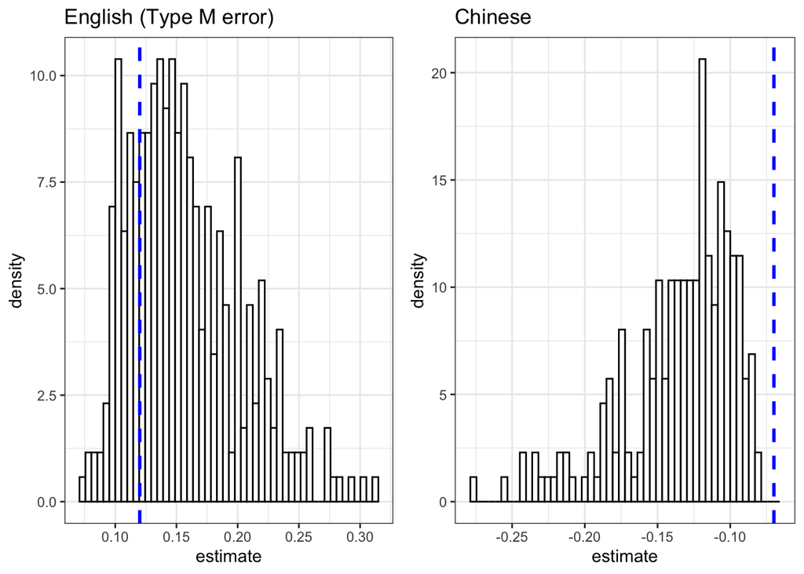

```r
gridExtra::grid.arrange(p1TypeM,p2TypeM,ncol=2)
```

# Frequentist LMMs for the RC data

Load the two data sets (bcogsci can be installed from github: https://github.com/bnicenboim/bcogsci).

```r
## ----loaddataEN-------------------------------------------------------------------------
library(bcogsci)
data("df_gg05_rc")
df_gg05_rc<-df_gg05_rc[c("subj","item","condition","RT")]
df_gg05_rc$condition<-factor(df_gg05_rc$condition,
                             levels=c("subjgap","objgap"))

df_gg05_rc$cond <- ifelse(df_gg05_rc$condition == "objgap", 1 / 2, -1 / 2)
## ignoring the singularity warning:
df_gg05_rc$logrt<-log(df_gg05_rc$RT)
m_gg05 <- lmer(logrt~cond + (1 + cond | subj) +
  (1 + cond || item), df_gg05_rc)
## summary(m_gg05)
```

```r
## ----loaddataCN,echo=TRUE-------------------------------------------------------------------------
data("df_gibsonwu")
## make the EN and CN columns identical:
df_gibsonwu$condition<-ifelse(df_gibsonwu$type=="obj-ext",
                              "objgap","subjgap")
df_gibsonwu$condition<-factor(df_gibsonwu$condition,
                              levels=c("subjgap","objgap"))
df_gibsonwu$RT<-df_gibsonwu$rt
df_gibsonwu$logrt<-log(df_gibsonwu$RT)
df_gibsonwu$cond<-ifelse(df_gibsonwu$condition=="objgap",+1/2,-1/2)
df_gibsonwu<-df_gibsonwu[c("subj","item","condition","RT","cond","logrt")]

m_gw <- lmer(logrt ~ cond + (1 + cond || subj) +
  (1 | item), df_gibsonwu)
#summary(m_gw)
```

# Power analysis using simulation

Not run (each loop takes 5-6 days on a Macbook Pro without any parallelization).

```r
subj_size<-c(50,100,200,300)
nsamp<-500
## English:
b_sampled<-extraDistr::rtnorm(nsamp,mean=0.12,sd=0.04,a=0.02,b=0.20)

power_est<-matrix(rep(NA,nsamp*length(subj_size)),nrow=length(subj_size))

for(j in 1:length(subj_size)){
   for(i in 1:nsamp){
     print(i)
     power_est[j,i] <- compute_power_freq(nitem = 16,
                    nsubj = subj_size[j],
                    beta = c(6, b_sampled[i]),
                           ranefsd = c(0.32, 0.22, 0.04, 0.09),
                           corr = c(.6, .6),
                           sigma_e = 0.31)
}
}

save(power_est,file="data/power_est.rda")

## Chinese:
subj_size<-c(50,100,200,300)
nsamp<-500
## Chinese estimate:
b_sampled<-extraDistr::rtnorm(nsamp,mean=-0.07,sd=0.05,a=-0.17,b=0.03)

power_estCN<-matrix(rep(NA,nsamp*length(subj_size)),nrow=length(subj_size))

for(j in 1:length(subj_size)){
   for(i in 1:nsamp){
     print(i)
     power_estCN[j,i] <- compute_power_freq(nitem = 16,
                           nsubj = subj_size[j],
                           beta = c(6, b_sampled[i]),
                           ranefsd = c(0.25, 0.11, 0.18, 0.0),
                           corr = c(.6, .6),
                           sigma_e = 0.52)
}
}

save(power_estCN,file="data/power_estCN.rda")
```

Load pre-computed power values:

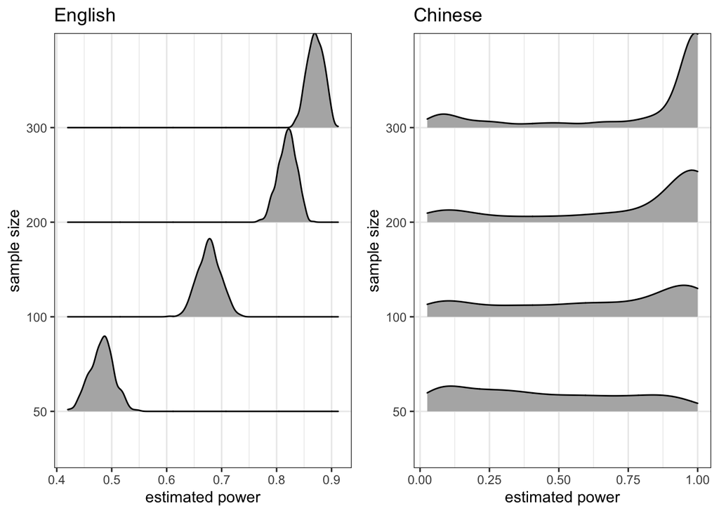

```r
## ----echo=TRUE,fig.height=3-----------------------------------------------------------------------
load("paper/data/power_est.rda")

## format for plotting:
power_EN<-data.frame(size=rep(c(50,100,200,300),each=500),
           power=c(power_est[1,],
                   power_est[2,],
                   power_est[3,],
                   power_est[4,]))

scl<-1

p1_powerEN<-ggplot(power_EN,
       aes(x = power, y = factor(size),
           height = ..density..
           )) +
  geom_density_ridges(scale = scl
                      ,stat = "density"
                      #rel_min_height = 0.01
                      ) +
  ggtitle("English")+
  ylab("sample size")+
  xlab("estimated power")+theme_bw()

load("paper/data/power_estCN.rda")

power_CN<-data.frame(size=rep(c(50,100,200,300),each=500),
           power=c(power_estCN[1,],
                   power_estCN[2,],
                   power_estCN[3,],
                   power_estCN[4,]))

p1_powerCN<-ggplot(power_CN,
       aes(x = power, y = factor(size),
           height = ..density..
           )) +
  geom_density_ridges(scale = scl
                      ,stat = "density"
                      #rel_min_height = 0.01
                      ) +
  ggtitle("Chinese")+
  ylab("sample size")+
  xlab("estimated power")+theme_bw()


gridExtra::grid.arrange(p1_powerEN,p1_powerCN,ncol=2)
```

The power distribution in Chinese is wider because the estimate of the fixed effect has a wide SE.

# After the data are collected

## Boxplots

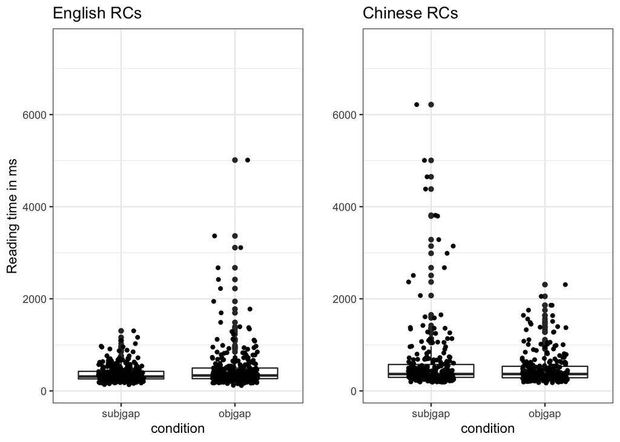

```r
## ----boxplots--------------------------------------------------------------
p1 <- ggplot(df_gg05_rc, aes(x=condition, y=RT)) +
  geom_boxplot() + ggtitle("English RCs")
p1<-p1+geom_jitter(shape=16, position=position_jitter(0.2))+theme_bw()+#scale_y_continuous(trans='log2')+
  ylab("Reading time in ms")+
  coord_cartesian(ylim = c(100,7500))


p1CN <- ggplot(df_gibsonwu, aes(x=condition, y=RT)) +
  geom_boxplot() + ggtitle("Chinese RCs")
p1CN<-p1CN+geom_jitter(shape=16,
                       position=position_jitter(0.2))+
  theme_bw()+#scale_y_continuous(trans='log2')+
  ylab("")+
  coord_cartesian(ylim = c(100,7500))

grid.arrange(p1, p1CN, ncol=2)
```

Use lmList function to compute individual estimates:

```r
## ----nopooling,echo=TRUE,warning=FALSE------------------------------------------------------------
mnopooling<-lmList(logrt~cond|subj,df_gg05_rc)
slopes_all<-coef(mnopooling)[,2]
#sort(slopes_all)
ints<-coef(mnopooling)[c(28,36,37),1]
slopes<-coef(mnopooling)[c(28,36,37),2]

subj28<-round(exp(ints[1]+slopes[1]/2)-exp(ints[1]-slopes[1]/2))
subj36<-round(exp(ints[2]+slopes[2]/2)-exp(ints[2]-slopes[2]/2))
subj37<-round(exp(ints[3]+slopes[3]/2)-exp(ints[3]-slopes[3]/2))
```

## xy-plots

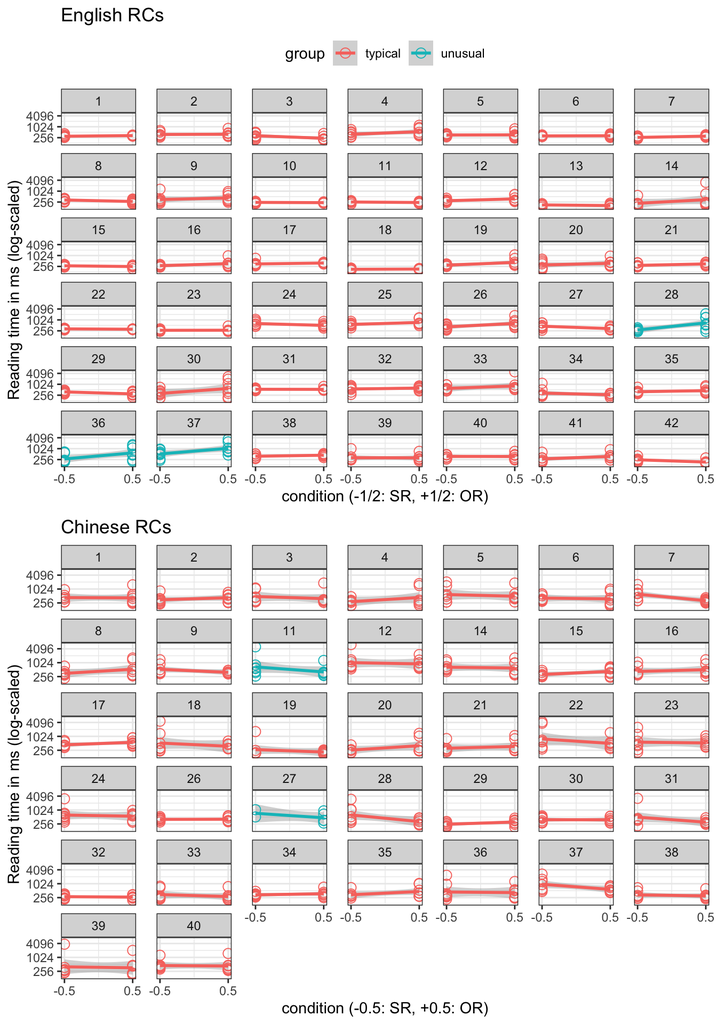

```r
## ----xyplot---------------------------------------------------
df_gg05_rc$group<-ifelse(df_gg05_rc$subj%in%c(28,36,37),"unusual","typical")
p2<- ggplot(data = df_gg05_rc, aes(
    x = cond,
    y = RT, color=group
  )) +
  scale_y_continuous(trans='log2') +
    facet_wrap( ~ subj) +
    geom_smooth(method = "lm") +
    geom_point(shape = 1, size = 3) +
    theme(panel.grid.minor = element_blank())+
    scale_x_continuous(breaks = round(seq(-1/2, 1/2, by = 1), 1)) +
    ylab("Reading time in ms (log-scaled)") +
    xlab("condition (-1/2: SR, +1/2: OR)")+
    theme_bw()+ggtitle("English RCs")+theme(panel.spacing.x = unit(1, "lines"))+theme(legend.position='top')

df_gibsonwu$group<-ifelse(df_gibsonwu$subj%in%c(11,27),"unusual","typical")
p2CN<- ggplot(data = df_gibsonwu, aes(
    x = cond,
    y = RT, color = group
  )) + scale_y_continuous(trans='log2')+
    facet_wrap( ~ subj) +
    geom_smooth(method = "lm") +
    geom_point(shape = 1, size = 3) +
    theme(panel.grid.minor = element_blank())+
    scale_x_continuous(breaks = round(seq(-1/2, 1/2, by = 1), 1)) +
    ylab("Reading time in ms (log-scaled)") +
    xlab("condition (-0.5: SR, +0.5: OR)")+
    theme_bw()+ggtitle("Chinese RCs")+theme(panel.spacing.x = unit(1, "lines"))+theme(legend.position='none')


gridExtra::grid.arrange(p2,p2CN,ncol=1)
```

# Violation of the Normality assumption

E.g., in the Chinese data, fitting the data on raw RTs gives a significant result, but this is driven by only two extreme data points in the SR condition.

```r
## ----fitlmmrawCN------------------------------------------------------------------------
m_gibsonwuraw <- lmer(RT~cond + (1 + cond || subj) +
  (1 + cond || item), df_gibsonwu)
t_raw<-summary(m_gibsonwuraw)$coefficients[2,3]
m_gibsonwurawreduced <- lmer(RT~cond + (1 + cond || subj) +
  (1 + cond || item), subset(df_gibsonwu,RT<5000))
t_rawred<-summary(m_gibsonwurawreduced)$coefficients[2,3]
```

# t-tests: Aggregation can mislead

```r
## ----echo=TRUE------------------------------------------------------------------------------------
 ## overly strong evidence due to ignoring by item variability:
bysubjlogEN <- aggregate(logrt ~ subj + condition, mean, data = df_gg05_rc)

bysubjlogCN <- aggregate(logrt ~ subj + condition, mean, data = df_gibsonwu)

bysubjrawEN <- aggregate(RT ~ subj + condition, mean, data = df_gg05_rc)

bysubjrawCN <- aggregate(RT ~ subj + condition, mean, data = df_gibsonwu)
```

```r
## ----englishttest-----------------------------------------------------------------------
## pseudoreplication problem:

t_res_indEN<-summary_ttest(t.test(logrt~condition,paired=TRUE,
                                  df_gg05_rc))
# normality problem:
## aggregated:

meansEN<-with(bysubjrawEN,tapply(RT,condition,mean))
sdsEN<-with(bysubjrawEN,tapply(RT,condition,sd))

t_res_normEN<-summary_ttest(t.test(RT~condition,
                                   paired=TRUE,
                                   bysubjrawEN))
## both ind and norm problem:
t_res_indnormEN<-summary_ttest(t.test(RT~condition,paired=TRUE,
                                  df_gg05_rc))

## correct t-test:
t_res_correctEN<-summary_ttest(t.test(logrt~condition,
                                      paired=TRUE,bysubjlogEN))
```

```r
## ----chinessettest----------------------------------------------------------------------
df_gibsonwu27<-subset(df_gibsonwu,subj!=27)

## pseudoreplication problem:
t_res_indCN<-summary_ttest(t.test(logrt~condition,paired=TRUE,
                                  df_gibsonwu27))
# normality problem:
## aggregated:
t_res_normCN<-summary_ttest(t.test(RT~condition,paired=TRUE,
                                   bysubjrawCN))
## both ind and norm problem:
t_res_indnormCN<-summary_ttest(t.test(RT~condition,paired=TRUE,
                                  df_gibsonwu27))

## correct t-test:
t_res_correctCN<-summary_ttest(t.test(logrt~condition,
                                      paired=TRUE,
                                      bysubjlogCN))
```

## Raw vs log RTs

Notice that models using raw RTs generate negative reading times.

```r
## ----rawvslog---------------------------------------------------------------------------
 ## show predicted data from these two models:
 m1raw<-lmer(RT ~ cond + (1+cond||subj) + (1+cond||item), df_gg05_rc ,
             control = lmerControl(
      optimizer = "nloptwrap",
      calc.derivs = FALSE
    ))
 ## summary(m1raw)

 m1log<-lmer(log(RT) ~ cond + (1+cond||subj) + (1+cond||item), df_gg05_rc,
             control = lmerControl(
      optimizer = "nloptwrap",
      calc.derivs = FALSE
    ))
 ## summary(m1log)

 m1rawCN<-lmer(RT ~ cond + (1+cond||subj) + (1+cond||item), df_gibsonwu,control = lmerControl(
      optimizer = "nloptwrap",
      calc.derivs = FALSE
    ) )
 ## summary(m1raw)

 m1logCN<-lmer(logrt ~ cond + (1+cond||subj) + (1+cond||item), df_gibsonwu,
               control = lmerControl(
      optimizer = "nloptwrap",
      calc.derivs = FALSE
    ))
```

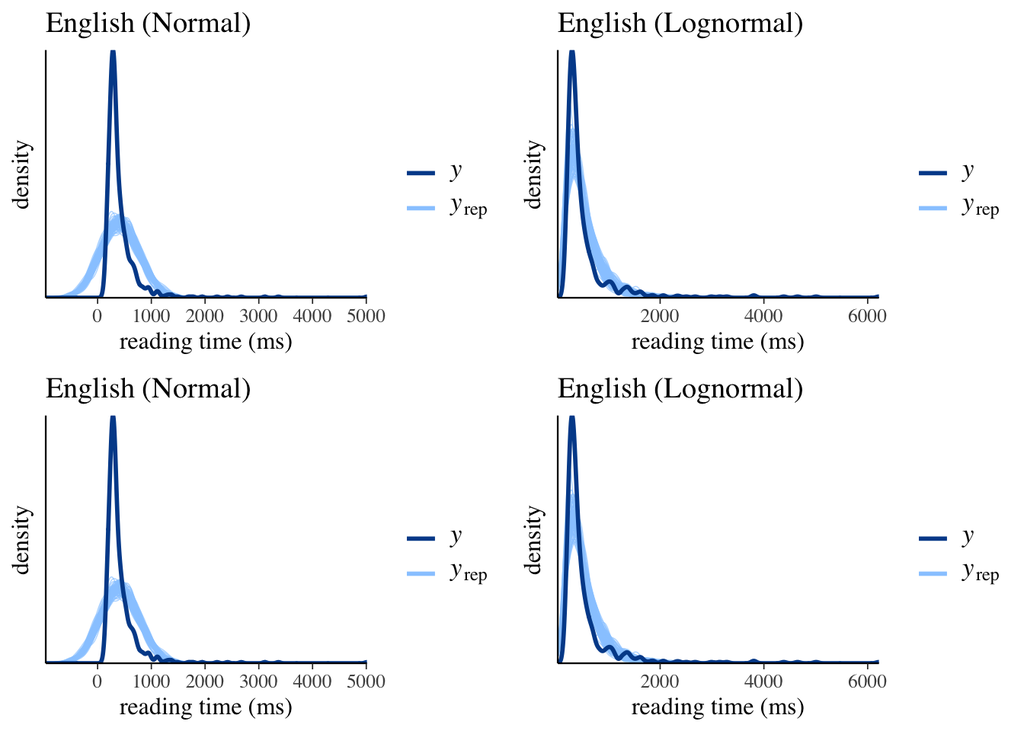

```r
## ----comparelograwEN---------------------------------------------------------
 ## Generate fake normally distributed data:
 nrep<-100
 normal_fake<-matrix(rep(NA,nrep*672),nrow=nrep)
 for(i in 1:nrep){
 normal_fake[i,]<-gen_fake_norm()$rt
 }

 ## Generate lognormal data:
  lognormal_fake<-matrix(rep(NA,nrep*672),nrow=nrep)
 for(i in 1:nrep){
 lognormal_fake[i,]<-gen_fake_lnorm()$rt
 }


## ----comparelograwCN---------------------------------------------------------
## Generate fake Chinese data from normal:
 normal_fakeCN<-matrix(rep(NA,nrep*672),nrow=nrep)
 for(i in 1:nrep){
 normal_fakeCN[i,]<-gen_fake_norm(nitem = 16,
                           nsubj = 42,
                           beta = c(548, -120),
                           ranefsd = c(148,35,150,111),
                           corr = c(.6, .6),
                           sigma_e = 557)$rt
 }

## Generate lognormal for Chinese:
  lognormal_fakeCN<-matrix(rep(NA,nrep*672),nrow=nrep)
 for(i in 1:nrep){
 lognormal_fakeCN[i,]<-gen_fake_lnorm(nitem = 16,
                           nsubj = 42,
                           beta = c(6.06208, -0.07161),
                           ranefsd = c(0.2446,0.1120,0.1809,0),
                           corr = c(.6, .6),
                           sigma_e = 0.5148 )$rt
 }


## ----showlograw,echo=TRUE,fig.width=7-------------------------------------------------------------
color_scheme_set("brightblue")

p1ENnorm<-ppc_dens_overlay(df_gg05_rc$RT,
                           normal_fake[,1:length(df_gg05_rc$RT)]) +
          xlab("reading time (ms)")+ylab("density") +
  ggtitle("English (Normal)")
p1ENlnorm<-ppc_dens_overlay(df_gibsonwu$RT,
                           lognormal_fakeCN[,1:length(df_gibsonwu$RT)]) +
          xlab("reading time (ms)")+ylab("density") +
  ggtitle("English (Lognormal)")

p2CNnorm<-ppc_dens_overlay(df_gibsonwu$RT,
                           normal_fakeCN[,1:length(df_gibsonwu$RT)]) +
          xlab("reading time (ms)")+ylab("density") +
  ggtitle("Chinese (Normal)")
p2CNlnorm<-ppc_dens_overlay(df_gibsonwu$RT,
                           lognormal_fakeCN[,1:length(df_gibsonwu$RT)]) +
          xlab("reading time (ms)")+ylab("density") +
  ggtitle("Chinese (Lognormal)")

gridExtra::grid.arrange(p1ENnorm,p1ENlnorm,p1ENnorm,p1ENlnorm,ncol=2)
```

# Bayes factors analyses

Not run here.

## Prior: $beta \sim Normal(0,0.1)$

```r
priorsinf <- c(
  prior(normal(6, 0.6), class = Intercept),
  prior(normal(0, 0.1), class = b),
  prior(normal(0, 0.5), class = sigma),
  prior(normal(0, 0.5), class = sd),
  prior(lkj(2), class = cor))

fit_EN <- brm(RT ~ cond +
  (cond | subj) + (cond | item),
prior = priorsinf,
family=lognormal(),
warmup = 2000,
iter = 20000,
cores = 4,
control = list(adapt_delta = 0.9),
save_pars = save_pars(all = TRUE),
data = df_gg05_rc
)

priorsNULL <- c(
  prior(normal(6, 0.6), class = Intercept),
  prior(normal(0, 0.5), class = sigma),
  prior(normal(0, 0.5), class = sd),
  prior(lkj(2), class = cor))


fit_ENNULL <- brm(RT ~ 1 +
  (cond | subj) + (cond | item),
prior = priorsNULL,
family=lognormal(),
warmup = 2000,
iter = 20000,
cores = 4,
control = list(adapt_delta = 0.9),
save_pars = save_pars(all = TRUE),
data = df_gg05_rc
)

alphaEN<-c(as_draws_df(fit_EN)$Intercept)
betaEN<-c(as_draws_df(fit_EN)$b_cond)

RC_EN<-exp(alphaEN+betaEN/2)-exp(alphaEN-betaEN/2)

save(RC_EN,file="data/RC_EN.rda")

bfEN<-bayes_factor(fit_EN,fit_ENNULL)$bf

save(bfEN,file="data/bfEN.rda")

fit_CN <- brm(RT ~ cond +
  (cond | subj) + (cond | item),
prior = priorsinf,
family=lognormal(),
warmup = 2000,
iter = 20000,
cores = 4,
control = list(adapt_delta = 0.9),
save_pars = save_pars(all = TRUE),
data = df_gibsonwu)

alphaCN<-c(as_draws_df(fit_CN)$Intercept)
betaCN<-c(as_draws_df(fit_CN)$b_cond)

RC_CN<-exp(alphaCN+betaCN/2)-exp(alphaCN-betaCN/2)

save(RC_CN,file="data/RC_CN.rda")

fit_CNNULL <- brm(RT ~ 1 +
  (cond | subj) + (cond | item),
prior = priorsNULL,
family=lognormal(),
warmup = 2000,
iter = 20000,
cores = 4,
control = list(adapt_delta = 0.9),
save_pars = save_pars(all = TRUE),
data = df_gibsonwu
)

bfCN<-bayes_factor(fit_CN,fit_CNNULL)$bf

save(bfCN,file="data/bfCN.rda")
```

## Prior: $beta \sim Normal(0,1)$

```r
priorsuninfnormal <- c(
  prior(normal(6, 0.6), class = Intercept),
  prior(normal(0,1), class = b),
  prior(normal(0, 0.5), class = sigma),
  prior(normal(0, 0.5), class = sd),
  prior(lkj(2), class = cor))

fit_EN2normal <- brm(RT ~ cond +
  (cond | subj) + (cond | item),
prior = priorsuninfnormal,
family=lognormal(),
warmup = 2000,
iter = 20000,
cores = 4,
control = list(adapt_delta = 0.9),
save_pars = save_pars(all = TRUE),
data = df_gg05_rc
)

priorsNULL <- c(
  prior(normal(6, 0.6), class = Intercept),
  prior(normal(0, 0.5), class = sigma),
  prior(normal(0, 0.5), class = sd),
  prior(lkj(2), class = cor))


fit_ENNULL <- brm(RT ~ 1 +
  (cond | subj) + (cond | item),
prior = priorsNULL,
family=lognormal(),
warmup = 2000,
iter = 20000,
cores = 4,
control = list(adapt_delta = 0.9),
save_pars = save_pars(all = TRUE),
data = df_gg05_rc
)

alphaEN2normal<-c(as_draws_df(fit_EN2normal)$Intercept)
betaEN2normal<-c(as_draws_df(fit_EN2normal)$b_cond)

RC_EN2normal<-exp(alphaEN2normal+betaEN2normal/2)-exp(alphaEN2normal-betaEN2normal/2)

save(RC_EN2normal,file="data/RC_EN2normal.rda")

bfEN2normal<-bayes_factor(fit_EN2normal,fit_ENNULL)$bf

save(bfEN2normal,file="data/bfEN2normal.rda")

fit_CN2normal <- brm(RT ~ cond +
  (cond | subj) + (cond | item),
prior = priorsuninfnormal,
family=lognormal(),
warmup = 2000,
iter = 20000,
cores = 4,
control = list(adapt_delta = 0.9),
save_pars = save_pars(all = TRUE),
data = df_gibsonwu)

alphaCN2normal<-c(as_draws_df(fit_CN2normal)$Intercept)
betaCN2normal<-c(as_draws_df(fit_CN2normal)$b_cond)

RC_CN2normal<-exp(alphaCN2normal+betaCN2normal/2)-exp(alphaCN2normal-betaCN2normal/2)

save(RC_CN2normal,file="data/RC_CN2normal.rda")

fit_CNNULL <- brm(RT ~ 1 +
  (cond | subj) + (cond | item),
prior = priorsNULL,
family=lognormal(),
warmup = 2000,
iter = 20000,
cores = 4,
control = list(adapt_delta = 0.9),
save_pars = save_pars(all = TRUE),
data = df_gibsonwu
)

bfCN2normal<-bayes_factor(fit_CN2normal,fit_CNNULL)$bf

save(bfCN2normal,file="data/bfCN2normal.rda")
```

## Prior: $beta \sim Cauchy(0,1)$

This doesn’t appear in the paper.

```r
priorsuninf <- c(
  prior(normal(6, 0.6), class = Intercept),
  prior(cauchy(0,1), class = b),
  prior(normal(0, 0.5), class = sigma),
  prior(normal(0, 0.5), class = sd),
  prior(lkj(2), class = cor))

fit_EN2 <- brm(RT ~ cond +
  (cond | subj) + (cond | item),
prior = priorsuninf,
family=lognormal(),
warmup = 2000,
iter = 20000,
cores = 4,
control = list(adapt_delta = 0.9),
save_pars = save_pars(all = TRUE),
data = df_gg05_rc
)

priorsNULL <- c(
  prior(normal(6, 0.6), class = Intercept),
  prior(cauchy(0, 0.5), class = sigma),
  prior(cauchy(0, 0.5), class = sd),
  prior(lkj(2), class = cor))


fit_ENNULL <- brm(RT ~ 1 +
  (cond | subj) + (cond | item),
prior = priorsNULL,
family=lognormal(),
warmup = 2000,
iter = 20000,
cores = 4,
control = list(adapt_delta = 0.9),
save_pars = save_pars(all = TRUE),
data = df_gg05_rc
)

alphaEN2<-c(as_draws_df(fit_EN2)$Intercept)
betaEN2<-c(as_draws_df(fit_EN2)$b_cond)

RC_EN2<-exp(alphaEN2+betaEN2/2)-exp(alphaEN2-betaEN2/2)
save(RC_EN2,file="data/RC_EN2.rda")

bfEN2<-bayes_factor(fit_EN2,fit_ENNULL)$bf
save(bfEN2,file="data/bfEN2.rda")

fit_CN2 <- brm(RT ~ cond +
  (cond | subj) + (cond | item),
prior = priorsuninf,
family=lognormal(),
warmup = 2000,
iter = 20000,
cores = 4,
control = list(adapt_delta = 0.9),
save_pars = save_pars(all = TRUE),
data = df_gibsonwu)

alphaCN2<-c(as_draws_df(fit_CN2)$Intercept)
betaCN2<-c(as_draws_df(fit_CN2)$b_cond)

RC_CN2<-exp(alphaCN2+betaCN2/2)-exp(alphaCN2-betaCN2/2)
save(RC_CN2,file="data/RC_CN2.rda")


fit_CNNULL <- brm(RT ~ 1 +
  (cond | subj) + (cond | item),
prior = priorsNULL,
family=lognormal(),
warmup = 2000,
iter = 20000,
cores = 4,
control = list(adapt_delta = 0.9),
save_pars = save_pars(all = TRUE),
data = df_gibsonwu
)

bfCN2<-bayes_factor(fit_CN2,fit_CNNULL)$bf

save(bfCN2,file="data/bfCN2.rda")
```

## Prior: $\beta \sim Normal(0.02,0.01)$

This is an informative prior that assumes that the effect is positive but small. The null is not a point value here, but rather a range of values around 0. This just illustrates that one need not be restricted to a point null.

```r
priorsnonzero <- c(
  prior(normal(6, 0.6), class = Intercept),
  prior(normal(0.02,0.01), class = b),
  prior(normal(0, 0.5), class = sigma),
  prior(normal(0, 0.5), class = sd),
  prior(lkj(2), class = cor))

priorsnonzeroCN <- c(
  prior(normal(6, 0.6), class = Intercept),
  prior(normal(-0.02,0.01), class = b),
  prior(normal(0, 0.5), class = sigma),
  prior(normal(0, 0.5), class = sd),
  prior(lkj(2), class = cor))


fit_EN3 <- brm(RT ~ cond +
  (cond | subj) + (cond | item),
prior = priorsnonzero,
family=lognormal(),
warmup = 2000,
iter = 20000,
cores = 4,
control = list(adapt_delta = 0.9),
save_pars = save_pars(all = TRUE),
data = df_gg05_rc
)

priorsNULLnonzero <- c(
  prior(normal(6, 0.6), class = Intercept),
  prior(normal(0,0.01), class = b),
  prior(normal(0, 0.5), class = sigma),
  prior(normal(0, 0.5), class = sd),
  prior(lkj(2), class = cor))


fit_ENNULLnonzero <- brm(RT ~ cond +
  (cond | subj) + (cond | item),
prior = priorsNULLnonzero,
family=lognormal(),
warmup = 2000,
iter = 20000,
cores = 4,
control = list(adapt_delta = 0.9),
save_pars = save_pars(all = TRUE),
data = df_gg05_rc
)

alphaEN3<-c(as_draws_df(fit_EN3)$Intercept)
betaEN3<-c(as_draws_df(fit_EN3)$b_cond)

RC_EN3<-exp(alphaEN3+betaEN3/2)-exp(alphaEN3-betaEN3/2)

save(RC_EN3,file="data/RC_EN3.rda")

bfEN3<-bayes_factor(fit_EN3,fit_ENNULLnonzero)$bf

save(bfEN3,file="data/bfEN3.rda")

fit_CN3 <- brm(RT ~ cond +
  (cond | subj) + (cond | item),
prior = priorsnonzeroCN,
family=lognormal(),
warmup = 2000,
iter = 20000,
cores = 4,
control = list(adapt_delta = 0.9),
save_pars = save_pars(all = TRUE),
data = df_gibsonwu)

alphaCN3<-c(as_draws_df(fit_CN3)$Intercept)
betaCN3<-c(as_draws_df(fit_CN3)$b_cond)

RC_CN3<-exp(alphaCN3+betaCN3/2)-exp(alphaCN3-betaCN3/2)

save(RC_CN3,file="data/RC_CN3.rda")

fit_CNNULLnonzero <- brm(RT ~ cond +
  (cond | subj) + (cond | item),
prior = priorsNULLnonzero,
family=lognormal(),
warmup = 2000,
iter = 20000,
cores = 4,
control = list(adapt_delta = 0.9),
save_pars = save_pars(all = TRUE),
data = df_gibsonwu
)

bfCN3<-bayes_factor(fit_CN3,fit_CNNULLnonzero)$bf

save(bfCN3,file="data/bfCN3.rda")
```

## Prior: $\beta \sim Normal(0.02,0.01)$

This is also an enthusiastic prior, but this time the null is a point value (obviously, this makes much less sense but this is what we normally do in a frequentist ANOVA).

```r
priorszero <- c(
  prior(normal(6, 0.6), class = Intercept),
  prior(normal(0.02,0.01), class = b),
  prior(normal(0, 0.5), class = sigma),
  prior(normal(0, 0.5), class = sd),
  prior(lkj(2), class = cor))

priorszeroCN <- c(
  prior(normal(6, 0.6), class = Intercept),
  prior(normal(-0.02,0.01), class = b),
  prior(normal(0, 0.5), class = sigma),
  prior(normal(0, 0.5), class = sd),
  prior(lkj(2), class = cor))


fit_EN3zero <- brm(RT ~ cond +
  (cond | subj) + (cond | item),
prior = priorszero,
family=lognormal(),
warmup = 2000,
iter = 20000,
cores = 4,
control = list(adapt_delta = 0.9),
save_pars = save_pars(all = TRUE),
data = df_gg05_rc
)

priorsNULLzero <- c(
  prior(normal(6, 0.6), class = Intercept),
  prior(normal(0, 0.5), class = sigma),
  prior(normal(0, 0.5), class = sd),
  prior(lkj(2), class = cor))


fit_ENNULLzero <- brm(RT ~ 1 +
  (cond | subj) + (cond | item),
prior = priorsNULLzero,
family=lognormal(),
warmup = 2000,
iter = 20000,
cores = 4,
control = list(adapt_delta = 0.9),
save_pars = save_pars(all = TRUE),
data = df_gg05_rc
)

alphaEN3zero<-c(as_draws_df(fit_EN3zero)$Intercept)
betaEN3zero<-c(as_draws_df(fit_EN3zero)$b_cond)

RC_EN3zero<-exp(alphaEN3zero+betaEN3zero/2)-exp(alphaEN3zero-betaEN3zero/2)

save(RC_EN3zero,file="data/RC_EN3zero.rda")

bfEN3zero<-bayes_factor(fit_EN3zero,fit_ENNULLzero)$bf

save(bfEN3zero,file="data/bfEN3zero.rda")

fit_CN3zero <- brm(RT ~ cond +
  (cond | subj) + (cond | item),
prior = priorszeroCN,
family=lognormal(),
warmup = 2000,
iter = 20000,
cores = 4,
control = list(adapt_delta = 0.9),
save_pars = save_pars(all = TRUE),
data = df_gibsonwu)

alphaCN3zero<-c(as_draws_df(fit_CN3zero)$Intercept)
betaCN3zero<-c(as_draws_df(fit_CN3zero)$b_cond)

RC_CN3zero<-exp(alphaCN3zero+betaCN3zero/2)-exp(alphaCN3zero-betaCN3zero/2)

save(RC_CN3zero,file="data/RC_CN3zero.rda")

fit_CNNULLzero <- brm(RT ~ 1 +
  (cond | subj) + (cond | item),
prior = priorsNULLzero,
family=lognormal(),
warmup = 2000,
iter = 20000,
cores = 4,
control = list(adapt_delta = 0.9),
save_pars = save_pars(all = TRUE),
data = df_gibsonwu
)

bfCN3zero<-bayes_factor(fit_CN3zero,fit_CNNULLzero)$bf

save(bfCN3zero,file="data/bfCN3zero.rda")
```

Load precomputed BFs:

```r
## ----loadbfprecomputed,echo=TRUE------------------------------------------------------------------
## mildly informative Normal(0,0.1):
load("paper/data/RC_EN.rda")
load("paper/data/RC_CN.rda")
load("paper/data/bfEN.rda")
load("paper/data/bfCN.rda")

## Normal(0,1)
load("paper/data/RC_EN2normal.rda")
load("paper/data/RC_CN2normal.rda")
load("paper/data/bfEN2normal.rda")
load("paper/data/bfCN2normal.rda")

## Cauchy(0,1)
load("paper/data/RC_EN2.rda")
load("paper/data/RC_CN2.rda")
load("paper/data/bfEN2.rda")
load("paper/data/bfCN2.rda")

## Enthusiastic with non-zero null
load("paper/data/RC_EN3.rda")
load("paper/data/RC_CN3.rda")
load("paper/data/bfEN3.rda")
load("paper/data/bfCN3.rda")

## Enthusiastic with zero null
load("paper/data/RC_EN3zero.rda")
load("paper/data/RC_CN3zero.rda")
load("paper/data/bfEN3zero.rda")
load("paper/data/bfCN3zero.rda")
```

## Posterior distributions

I use the posterior from prior Normal(0,0.1).

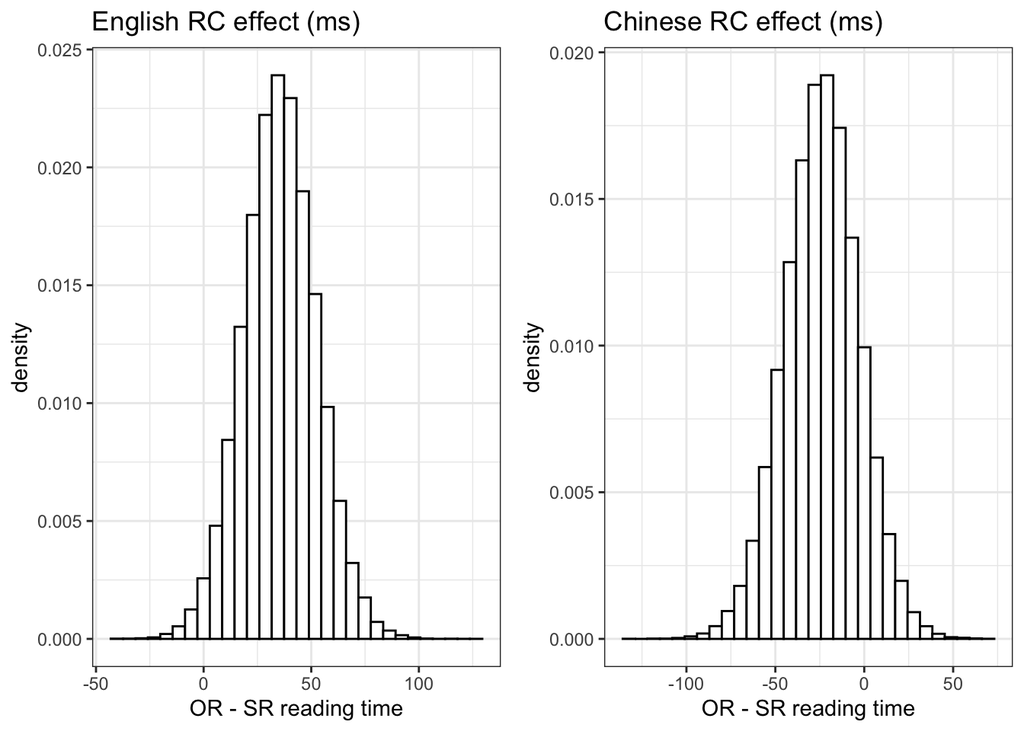

```r
## ----echo=TRUE,fig.height=2-----------------------------------------------------------------------
RC_EN<-data.frame(RC_EN)
RC_CN<-data.frame(RC_CN)

p1RCEN<-ggplot(RC_EN, aes(x=RC_EN)) +
 geom_histogram(aes(y=..density..), colour="black", fill="white")+theme_bw()+ggtitle("English RC effect (ms)")+xlab("OR - SR reading time")
p2RCCN<-ggplot(RC_CN, aes(x=RC_CN)) +
 geom_histogram(aes(y=..density..), colour="black", fill="white")+theme_bw()+ggtitle("Chinese RC effect (ms)")+xlab("OR - SR reading time")
gridExtra::grid.arrange(p1RCEN,p2RCCN,ncol=2)
```